# Time series I: EDA

Radu Ioan-Alexandru (Gr 405) Stefan Eva (Gr 405)

```
 09 ianuarie 2019
```

## Ex. 1

1. For the following series, find an appropriate Box-Cox transformation in order to stabilize the variance.

```r
# - usnetelec
lUsnetelec <- BoxCox.lambda(usnetelec)
print(c("Good value of lambda for usnetelec: ",
        lUsnetelec))
```

```
## [1] "Good value of lambda for usnetelec: "
## [2] "0.516771443964645"
```

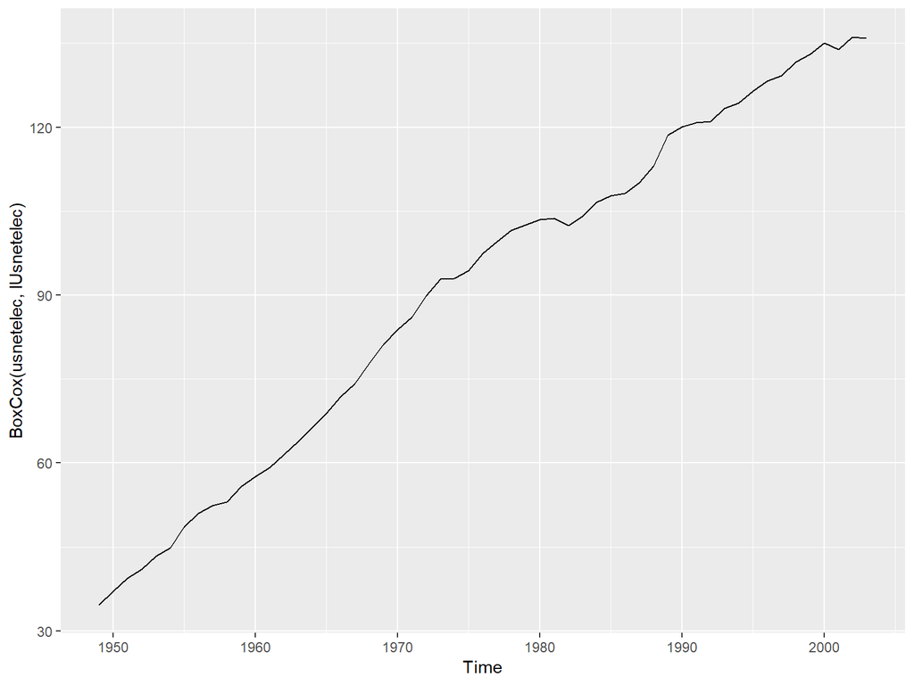

```r
autoplot(BoxCox(usnetelec, lUsnetelec))
```

```r
# - usgdp
lUsgdp <- BoxCox.lambda(usgdp)
print(c("Good value of lambda for usgdp: ",
      lUsgdp))
```

```
## [1] "Good value of lambda for usgdp: " "0.366352049520952"
```

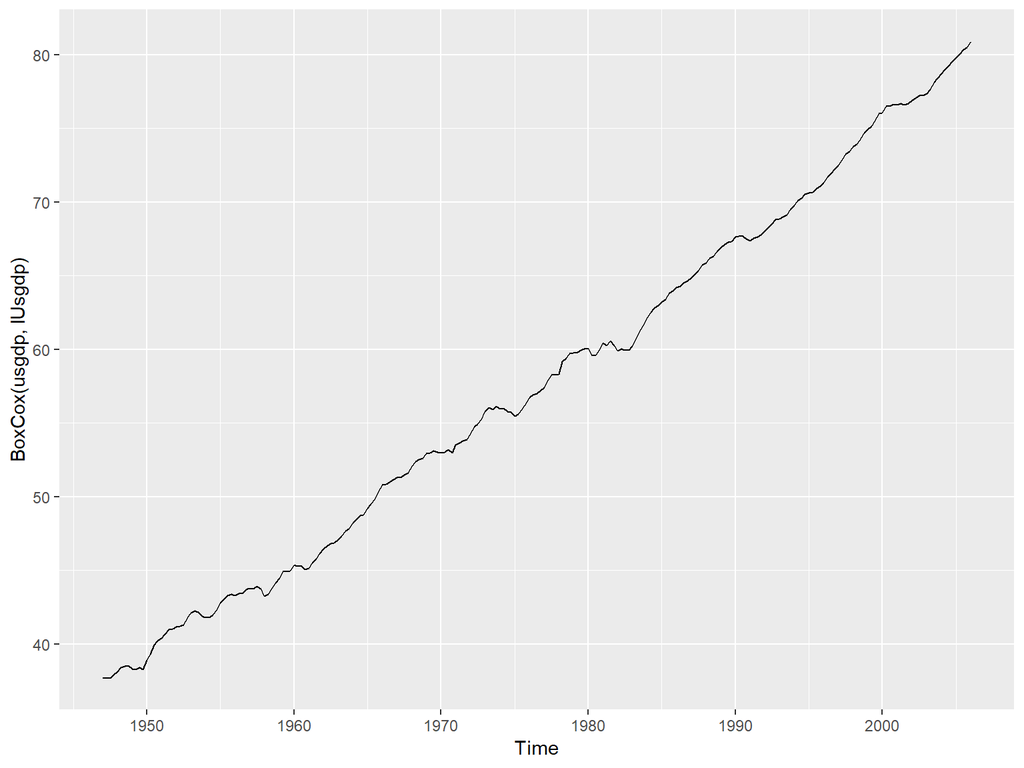

```r
autoplot(BoxCox(usgdp, lUsgdp))
```

```r
# - mcopper
lMcopper <- BoxCox.lambda(mcopper)
print(c("Good value of lambda for mcopper: ",
      lMcopper))
```

```
## [1] "Good value of lambda for mcopper: "
## [2] "0.191904709003829"
```

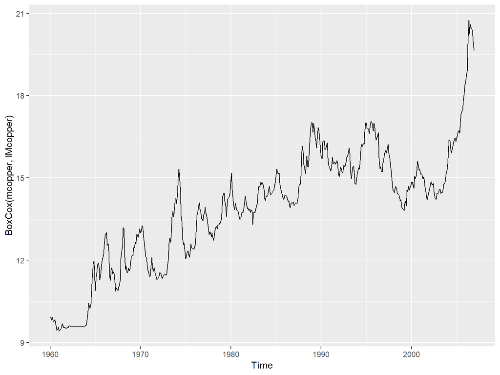

```r
autoplot(BoxCox(mcopper, lMcopper))
```

```r
# - enplanements
lEnplanements <- BoxCox.lambda(enplanements)
print(c("Good value of lambda for enplanements: ",
      lEnplanements))
```

```
## [1] "Good value of lambda for enplanements: "
## [2] "-0.226946111237065"
```

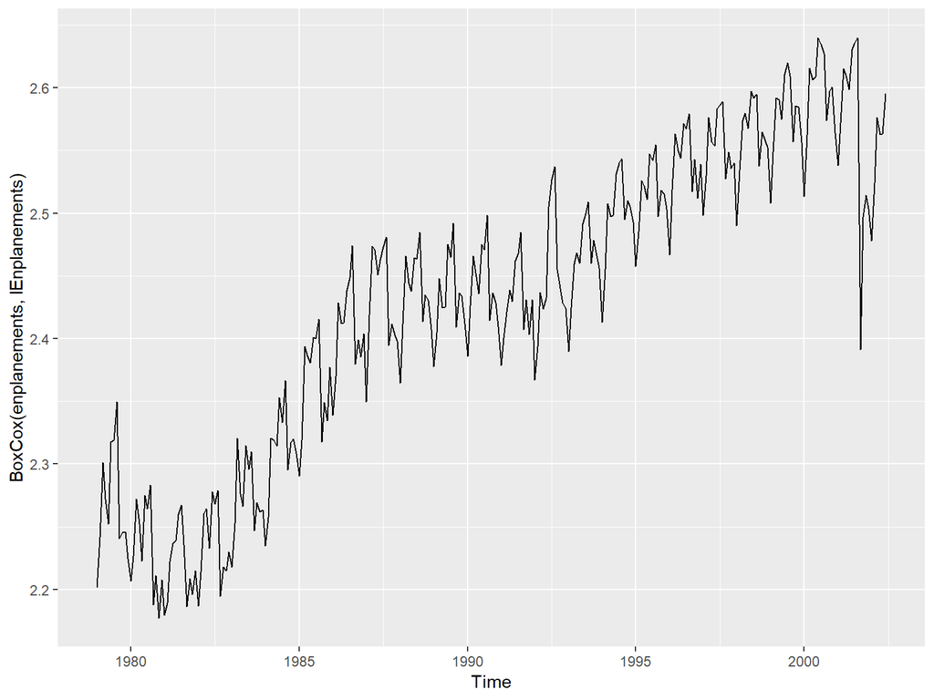

```r
autoplot(BoxCox(enplanements, lEnplanements))
```

## Ex. 2

2. Why is a Box-Cox transformation unhelpful for the cangas data?

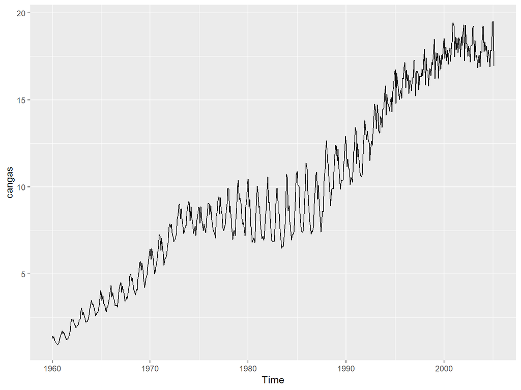

```r
autoplot(cangas)
```

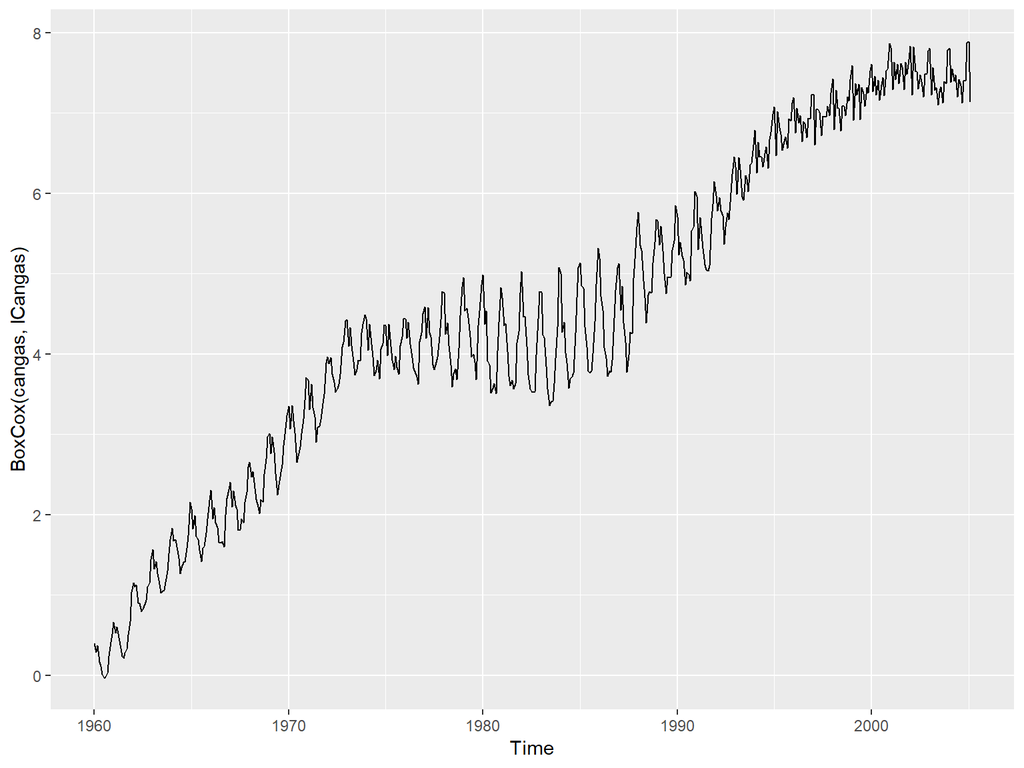

```r
lCangas <- BoxCox.lambda(cangas)
autoplot(BoxCox(cangas, lCangas))
```

```r
# You can see that the Box-Cox transformation doesn't yield simpler model
```

## Ex. 3

3. What Box-Cox transformation would you select for your retail data (from Exercise 3 in Section 2.10)?

```r
retaildata <- xlsx::read.xlsx("retail.xlsx", sheetIndex = 1, startRow = 2)
myts <- ts(retaildata[,"A3349873A"], frequency=12, start=c(1982,4))
lRetail <- BoxCox.lambda(myts)
print(c("selected lambda:", lRetail))
```

```
## [1] "selected lambda:"  "0.127636859661548"
```

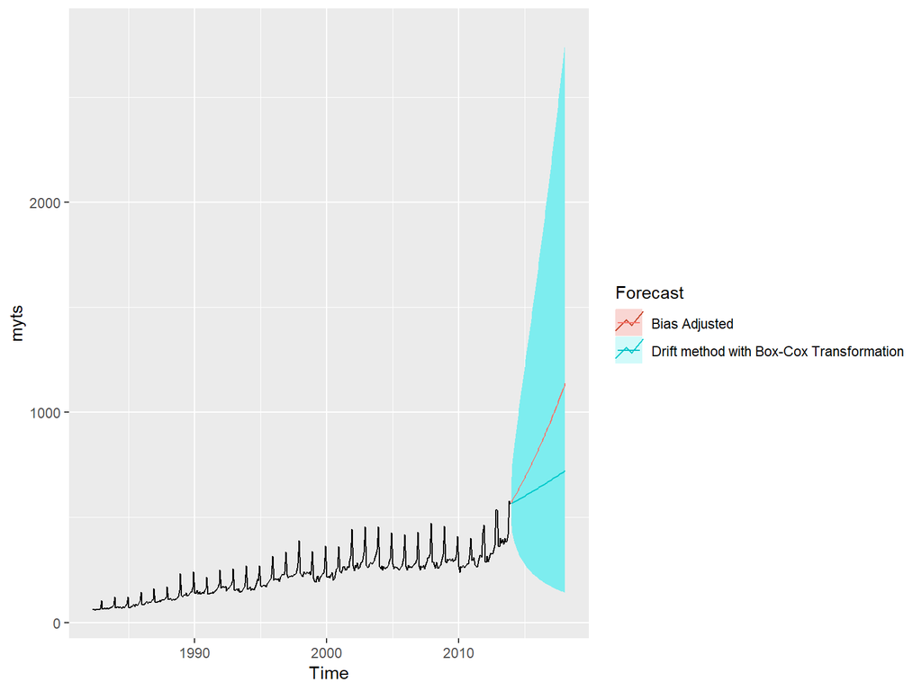

```r
fc_retail <- rwf(myts,
                 drift = TRUE,
                 lambda = lRetail,
                 h = 50,
                 level = 80)
fc_retail_biasadj <- rwf(myts,
                         drift = TRUE,
                         lambda = lRetail,
                         h = 50,
                         level = 80,
                         biasadj = TRUE)
autoplot(myts) +
  autolayer(fc_retail, series = "Drift method with Box-Cox Transformation") +
  autolayer(fc_retail_biasadj$mean, series = "Bias Adjusted") +
  guides(colour = guide_legend(title = "Forecast"))
```

```r
# It is better to choose a bias adjusted Box-Cox Transformation with lambda = 0.128
```

## Ex. 4

4. For each of the following series, make a graph of the data. If transforming seems appropriate, do so and describe the effect. dole, usdeaths, bricksq.

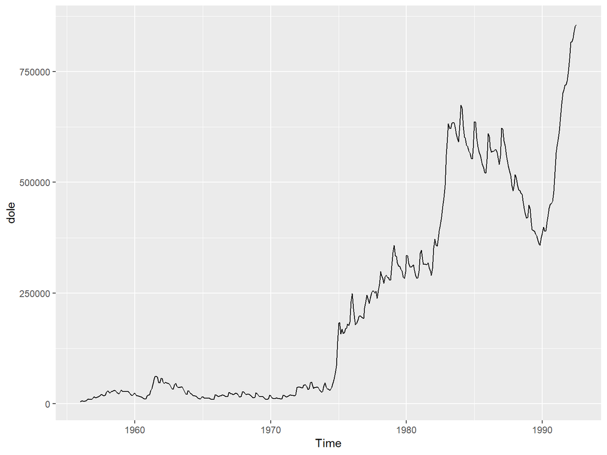

```r
autoplot(dole)
```

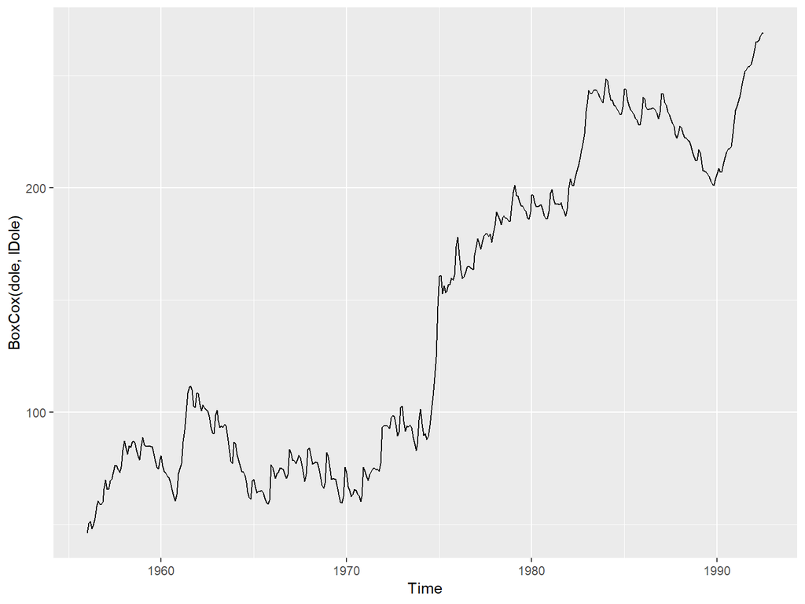

```r
lDole <- BoxCox.lambda(dole)
autoplot(BoxCox(dole, lDole))
```

```r
# For dole data, it looks like using Box-Cox Transformation is better to see the pattern.
```

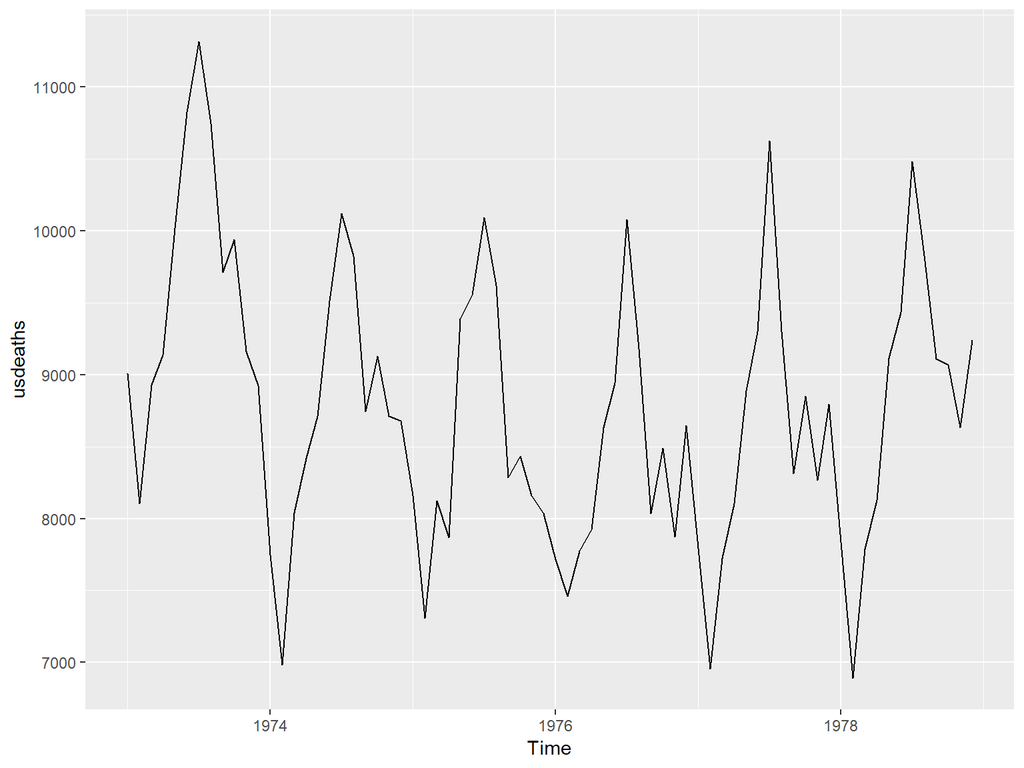

```r
autoplot(usdeaths)
```

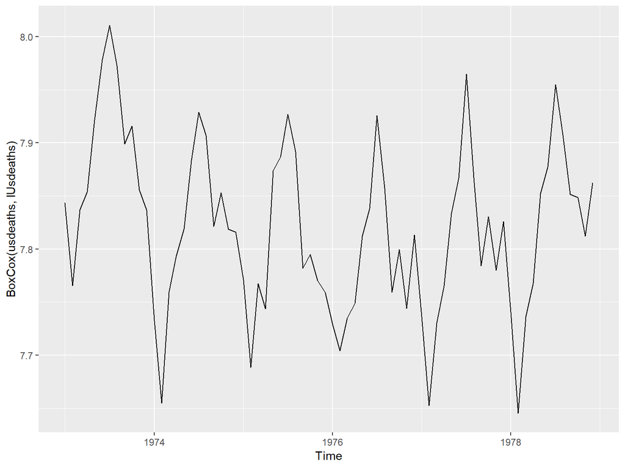

```r
lUsdeaths <- BoxCox.lambda(usdeaths)
autoplot(BoxCox(usdeaths, lUsdeaths))
```

```r
# For usdeaths data, it looks like it is meaningless to transform it.
```

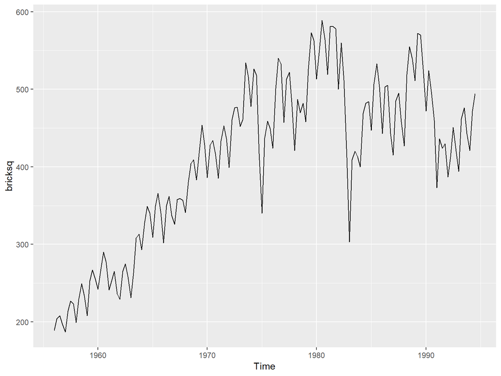

```r
autoplot(bricksq)
```

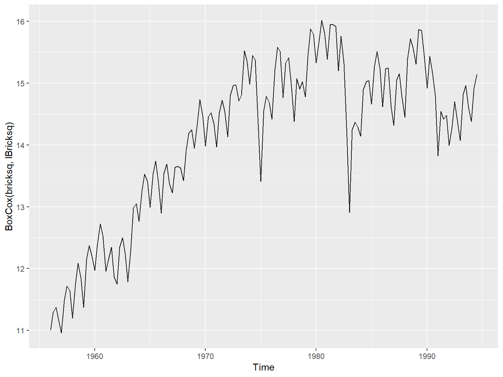

```r
lBricksq <- BoxCox.lambda(bricksq)
autoplot(BoxCox(bricksq, lBricksq))
```

```r
# For bricksq data, it looks like it is meaningless to transform it
```

## Ex. 5

5. Calculate the residuals from a seasonal naïve forecast applied to the quarterly Australian beer production data from 1992. Test if the residuals are white noise and normally distributed. What do you conclude?

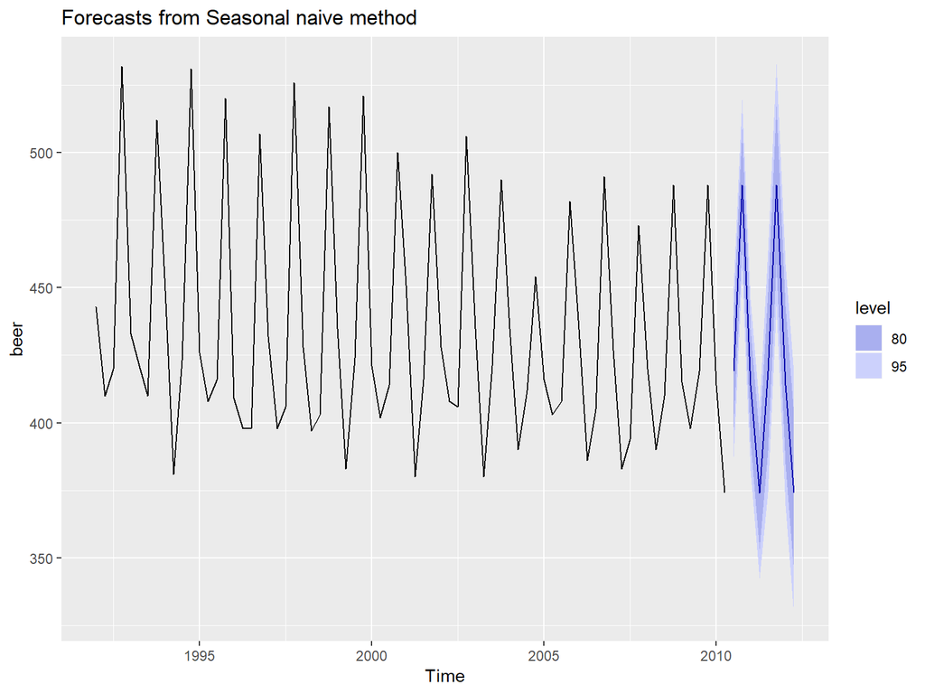

```r
beer <- window(ausbeer, start = 1992)
fc <- snaive(beer)
autoplot(fc)
```

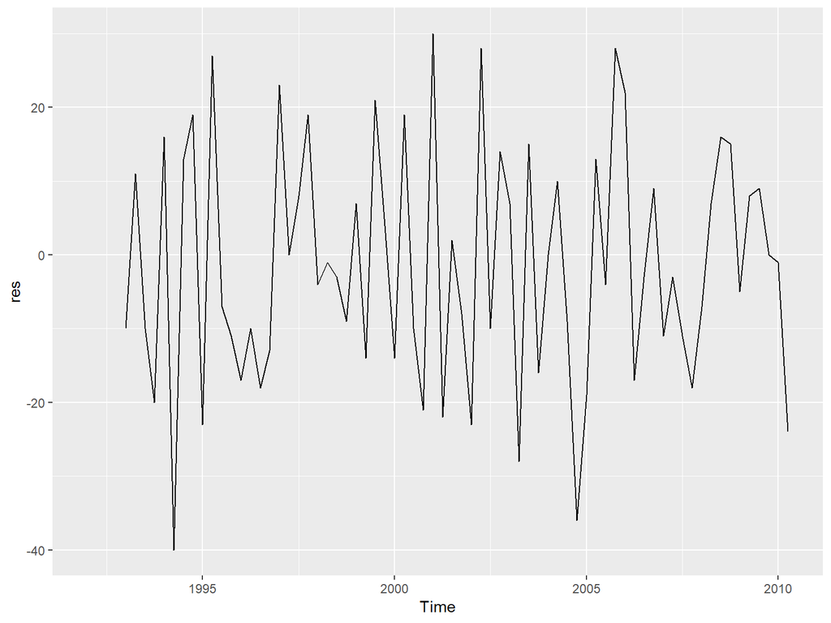

```r
res <- residuals(fc)
autoplot(res)
```

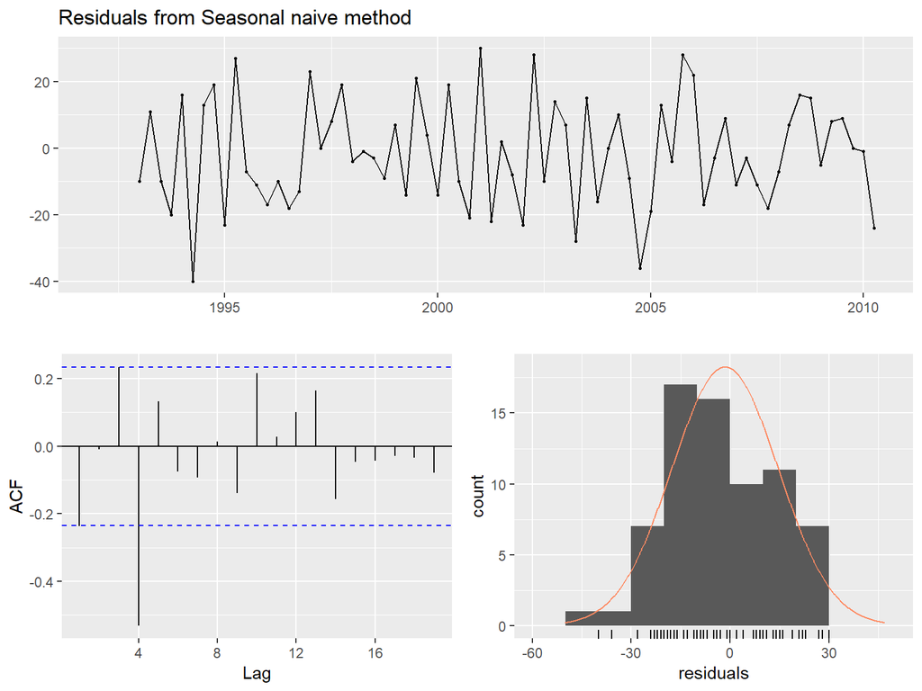

```
##
##  Ljung-Box test
##
## data:  Residuals from Seasonal naive method
## Q* = 32.269, df = 8, p-value = 8.336e-05
##
## Model df: 0.   Total lags used: 8
```

```r
checkresiduals(fc)
```

```r
# The ACF plot result indicates that the residuals aren't white noise because of significant spike at lag 4.
# Ljung-Box test shows that it is statistically significant.
# Therefore they aren't white noise and they aren't normally distributed.
```

## Ex. 6

6. Repeat the exercise for the WWWusage and bricksq data. Use whichever of naive or snaive is more appropriate in each case.

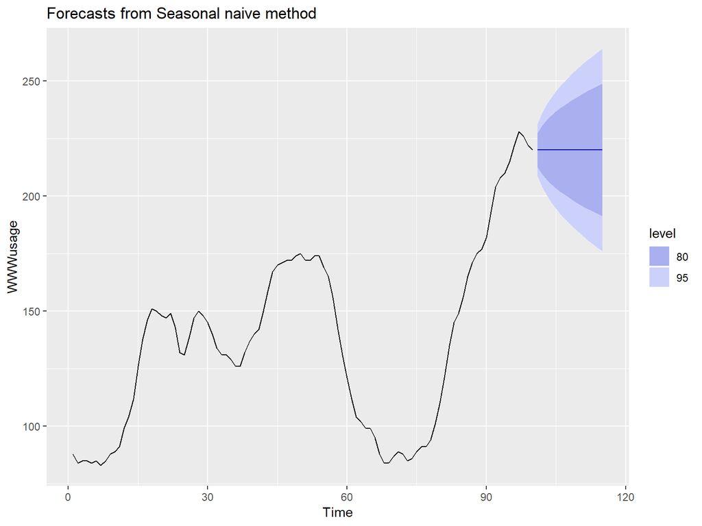

```r
snaiveWww <- snaive(WWWusage, h = 15)
autoplot(snaiveWww)
```

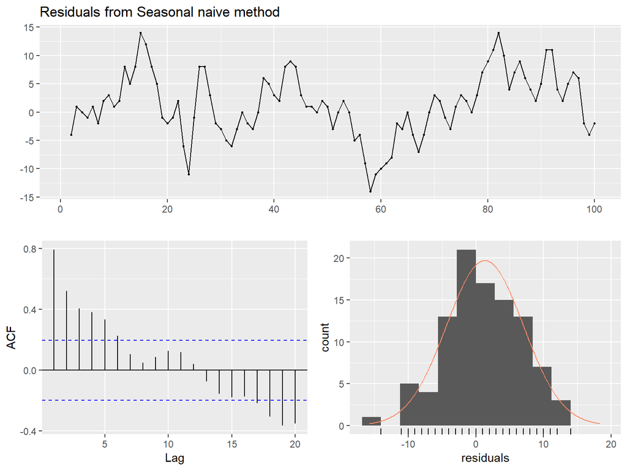

```
##
##  Ljung-Box test
##
## data:  Residuals from Seasonal naive method
## Q* = 145.58, df = 10, p-value < 2.2e-16
##
## Model df: 0.   Total lags used: 10
```

```r
checkresiduals(snaiveWww)
```

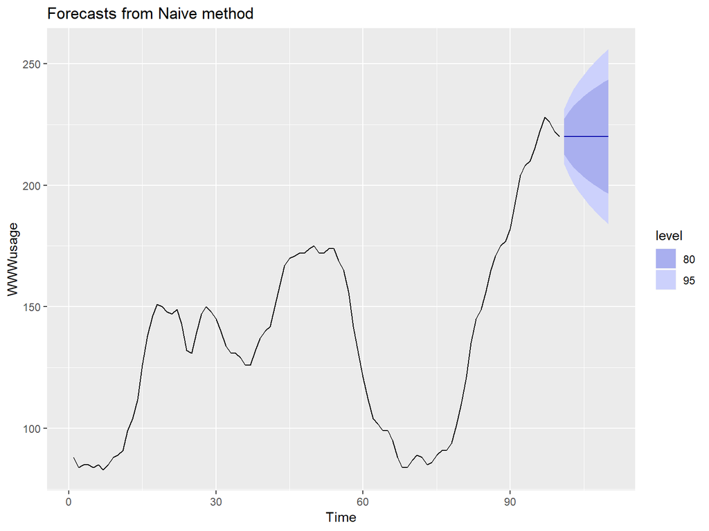

```r
naiveWww <- naive(WWWusage)
autoplot(naiveWww)
```

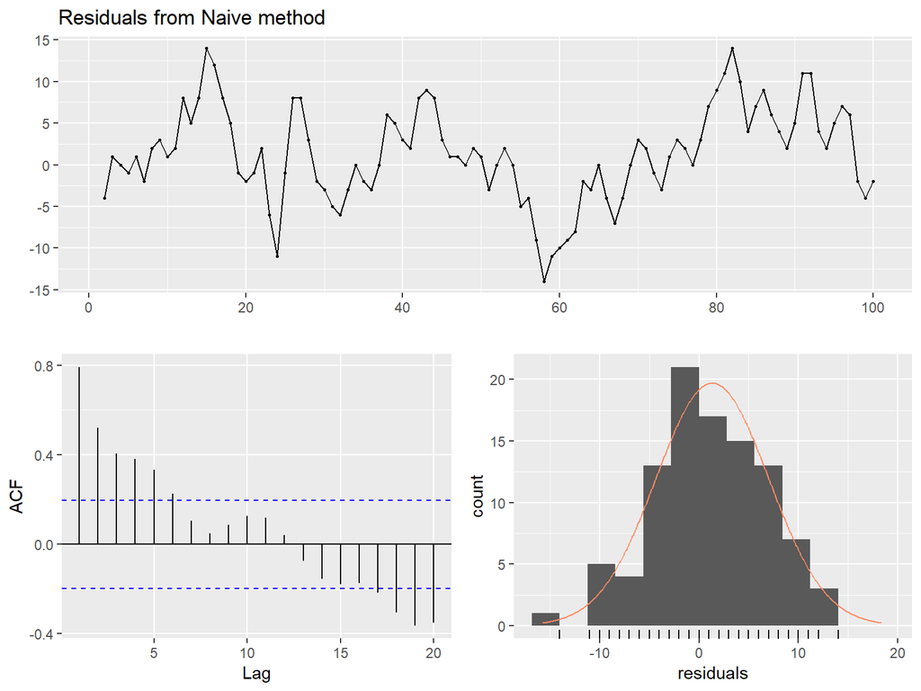

```
##
##  Ljung-Box test
##
## data:  Residuals from Naive method
## Q* = 145.58, df = 10, p-value < 2.2e-16
##
## Model df: 0.   Total lags used: 10
```

```r
checkresiduals(naiveWww)
```

```r
# The ACF plot indicates that the residuals aren't white noise because of existence of significant spikes.
# Ljung-Box test shows that they are statistically significant for both of methods.
# Therefore they aren't white noise. And the distribution of residuals isn't normal, too.
# We will choose the naive method because there isn't any particular seasonal pattern in the data and the Q values of Ljung-Box test were same for both methods.
```

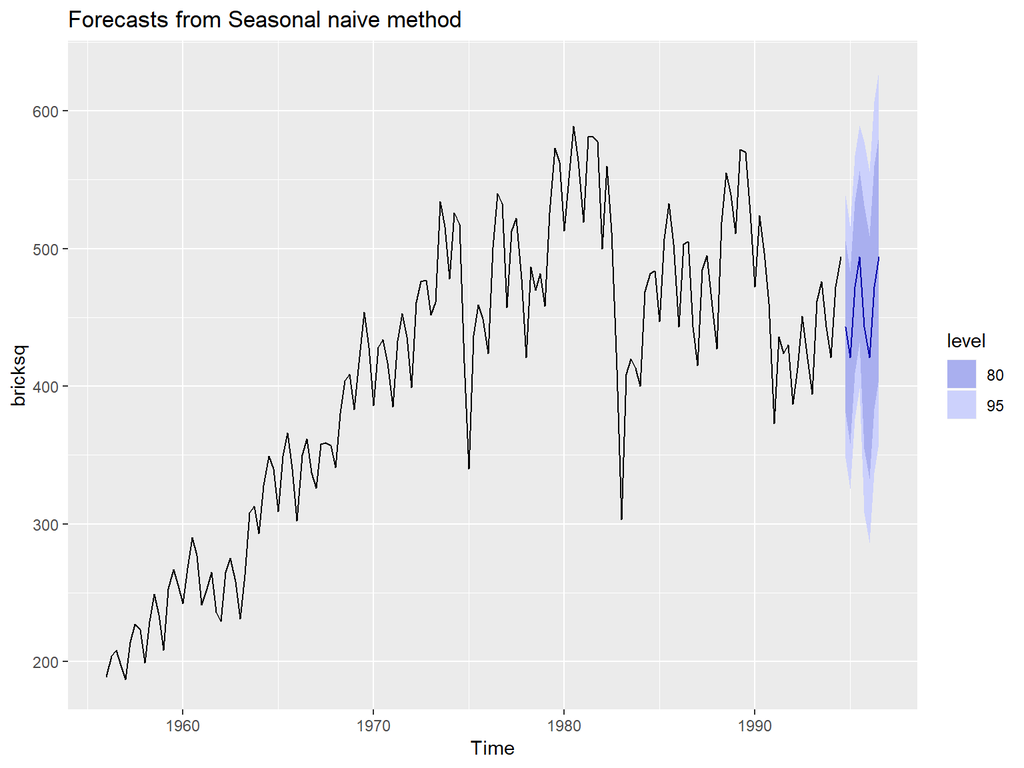

```r
snaiveBricksq <- snaive(bricksq)
autoplot(snaiveBricksq)
```

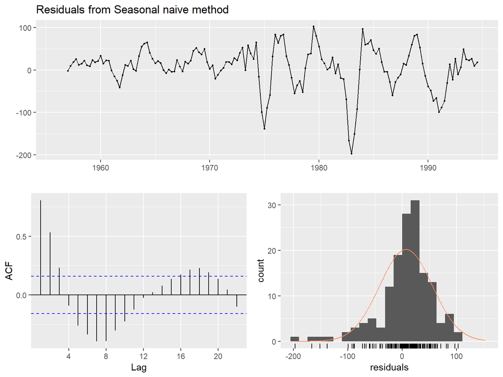

```
##
##  Ljung-Box test
##
## data:  Residuals from Seasonal naive method
## Q* = 233.2, df = 8, p-value < 2.2e-16
##
## Model df: 0.   Total lags used: 8
```

```r
checkresiduals(snaiveBricksq)
```

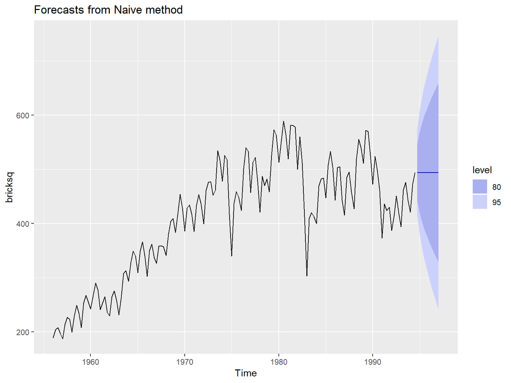

```r
naiveBricksq <- naive(bricksq)
autoplot(naiveBricksq)
```

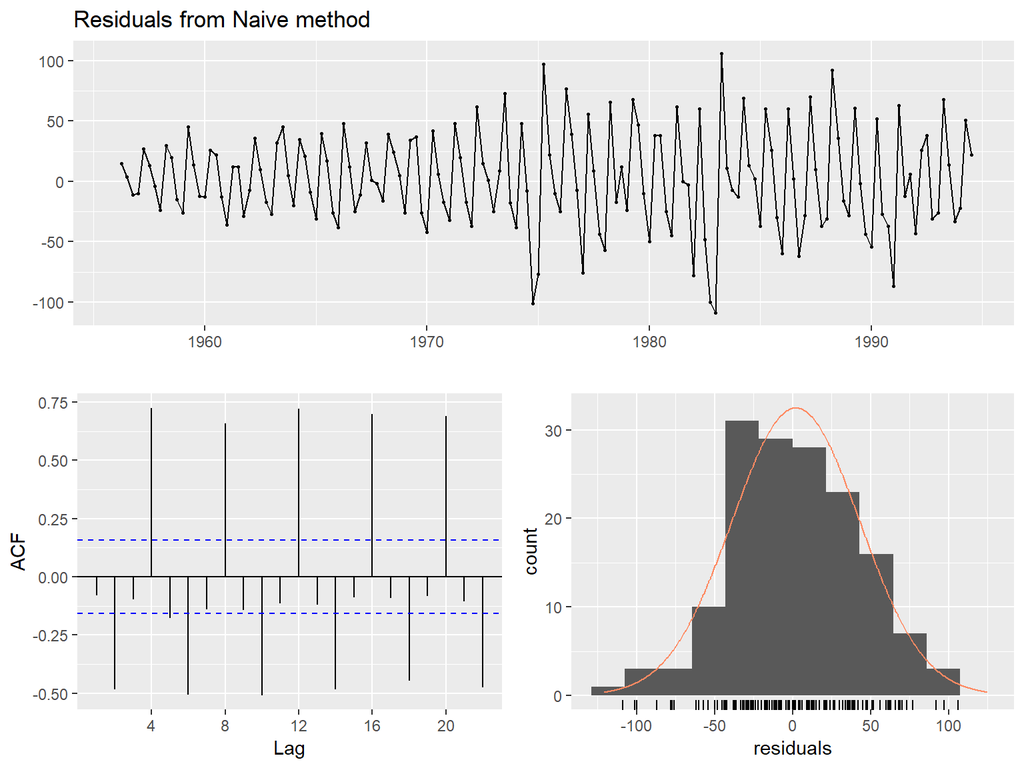

```
##
##  Ljung-Box test
##
## data:  Residuals from Naive method
## Q* = 244.43, df = 8, p-value < 2.2e-16
##
## Model df: 0.   Total lags used: 8
```

```r
checkresiduals(naiveBricksq)
```

```r
# For both of methods, Ljung-Box test results show that the residuals aren't white noise. And the residuals didn't have normal distribution, too.
# We will choose snaive method because we can see the seasonality in the data and the Q value of Ljung-Box of snaive methods was less than the value of naive method.
```

## Ex. 7

7. Are the following statements true or false? Explain your answer.
1. Good forecast methods should have normally distributed residuals.
2. A model with small residuals will give good forecasts.
3. The best measure of forecast accuracy is MAPE.
4. If your model doesn’t forecast well, you should make it more complicated.
5. Always choose the model with the best forecast accuracy as measured on the test set.

answer

- 1. It isn’t necessary for good forecast methods to have normally distributed residuals, but it is useful to have them.
- 2. Good forecast methods don’t need to have small residuals. But their residuals should be uncorrelated and have zero mean.
- 3. The best measure of forecast accuracy is different on a case by case basis.
- 4. More complicated forecast method doesn’t guarantee better forecast.
- 5. When choosing a model, whether the residuals have zero mean and whether they are uncorrelated with each other should also be considered. Simply choosing best accuracy model isn’t good.

## Ex. 8

8. For your retail time series (from Exercise 3 in Section 2.10):

```r
# a. Split the data into two parts using
myts.train <- window(myts, end=c(2010,12))
myts.test <- window(myts, start=2011)
```

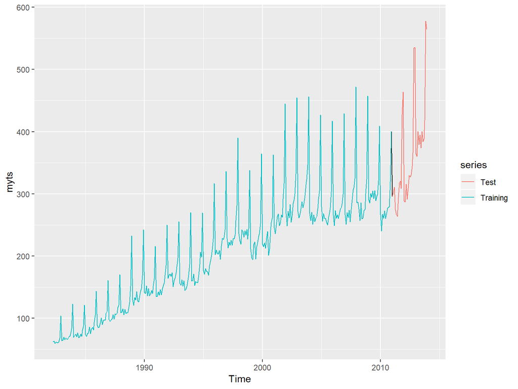

```r
# b. Check that your data have been split appropriately by producing the following plot.
autoplot(myts) +
  autolayer(myts.train, series="Training") +
  autolayer(myts.test, series="Test")
```

```r
# c. Calculate forecasts using snaive applied to myts.train.
snaive_myts_train <- snaive(myts.train)
```

```r
# d. Compare the accuracy of your forecasts against the actual values stored in myts.test.
accuracy(snaive_myts_train, myts.test)
```

```
##                     ME     RMSE      MAE       MPE      MAPE     MASE
## Training set  7.772973 20.24576 15.95676  4.702754  8.109777 1.000000
## Test set     55.300000 71.44309 55.78333 14.900996 15.082019 3.495907
##                   ACF1 Theil's U
## Training set 0.7385090        NA
## Test set     0.5315239  1.297866
```

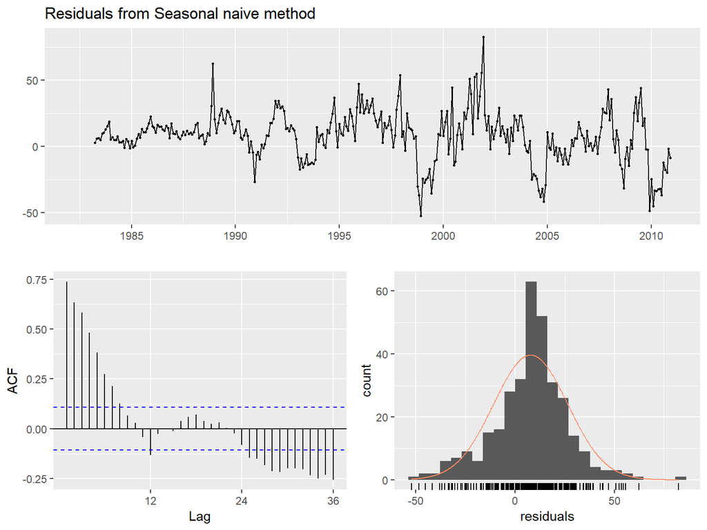

```
##
##  Ljung-Box test
##
## data:  Residuals from Seasonal naive method
## Q* = 624.45, df = 24, p-value < 2.2e-16
##
## Model df: 0.   Total lags used: 24
```

```r
# e. Check the residuals. Do the residuals appear to be uncorrelated and normally distributed?
checkresiduals(snaive_myts_train)
```

```r
# residuals were correlated with each other and not normally distributed
```

```r
# f. How sensitive are the accuracy measures to the training/test split?
# I thought of sensitivity as the ratio of the test set error to the train set error. When I used the definition, it looked like Mean Error is highly sensitive, RMSE, MAE, MPE, MASE are sensitive and MAPE and ACF1 aren't much sensitive.
# I don't know whether this method is what the author wanted to solve this question about sensitivity.
```

## Ex. 9

9. visnights contains quarterly visitor nights (in millions) from 1998 to 2016 for twenty regions of Australia.

```r
# a. Use window() to create three training sets for visnights[,"QLDMetro"], omitting the last 1, 2 and 3 years; call these train1, train2, and train3, respectively. For example train1 <- window(visnights[, "QLDMetro"], end = c(2015, 4))

temp = visnights[, "QLDMetro"]
train1 <- window(temp, end = c(2015, 4))
train2 <- window(temp, end = c(2014, 4))
train3 <- window(temp, end = c(2013, 4))
```

```r
# b. Compute one year of forecasts for each training set using the snaive() method. Call these fc1, fc2 and fc3, respectively

fc1 <- snaive(train1, h = 4)
fc2 <- snaive(train2, h = 4)
fc3 <- snaive(train3, h = 4)
```

```r
# c. Use accuracy() to compare the MAPE over the three test sets. Comment on these.

test1 <- window(temp, start = c(2016, 1), end = c(2016, 4))
test2 <- window(temp, start = c(2015, 1), end = c(2015, 4))
test3 <- window(temp, start = c(2014, 1), end = c(2014, 4))
accuracy(fc1, test1)
```

```
##                      ME      RMSE       MAE        MPE     MAPE      MASE
## Training set 0.02006107 1.0462821 0.8475553 -0.2237701 7.976760 1.0000000
## Test set     0.56983879 0.9358727 0.7094002  4.6191866 6.159821 0.8369957
##                    ACF1 Theil's U
## Training set 0.06014484        NA
## Test set     0.09003153 0.4842061
```

```r
writeLines("")
```

```r
accuracy(fc2, test2)
```

```
##                      ME      RMSE       MAE        MPE     MAPE      MASE
## Training set 0.01618760 1.0735582 0.8809432 -0.2744747 8.284216 1.0000000
## Test set     0.08203656 0.4117902 0.3133488  0.5875037 3.057463 0.3556969
##                     ACF1 Theil's U
## Training set  0.06610879        NA
## Test set     -0.59903247 0.3336559
```

```r
writeLines("")
```

```r
accuracy(fc3, test3)
```

```
##                        ME     RMSE       MAE        MPE     MAPE      MASE
## Training set -0.007455407 1.074544 0.8821694 -0.5625865 8.271365 1.0000000
## Test set      0.370832661 1.058658 0.8625501  4.0472032 8.476977 0.9777602
##                     ACF1 Theil's U
## Training set  0.07317746        NA
## Test set     -0.36890062  1.177346
```

```r
# MAPE was smallest for 2015 prediction and biggest for 2014 prediction. MAPE became smaller in 2016 prediction, but it wan't smaller than the one for 2015.
```

## Ex. 10

10. Use the Dow Jones index (data set dowjones) to do the following:

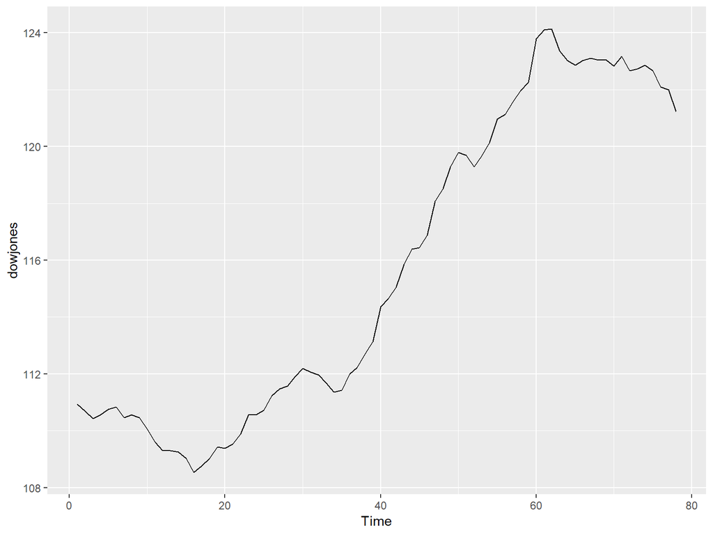

```r
# a. Produce a time plot of the series.
autoplot(dowjones)
```

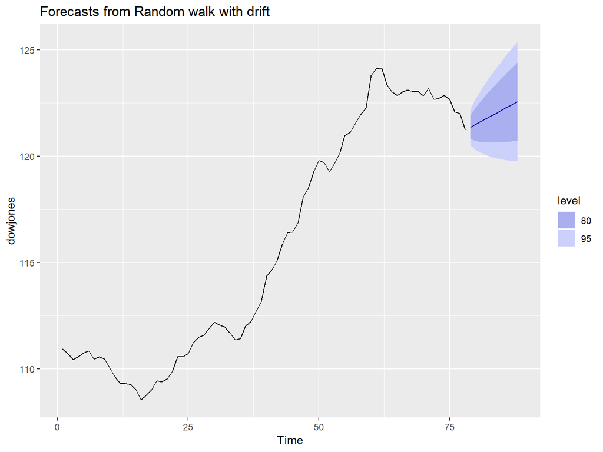

```r
# b. Produce forecasts using the drift method and plot them.
driftDj <- rwf(dowjones, drift = TRUE)
autoplot(driftDj)
```

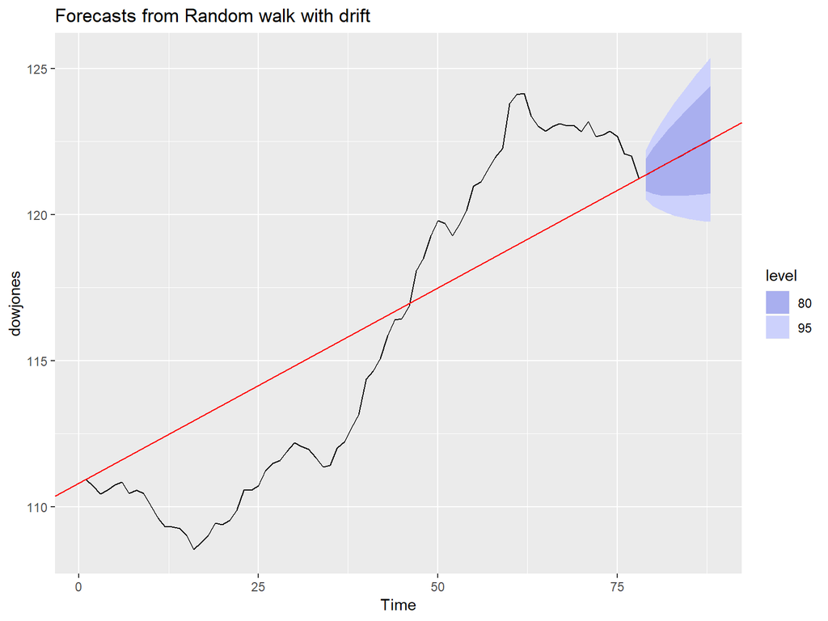

```r
# c. Show that the forecasts are identical to extending the line drawn between the first and last observations.
dj_x <- c(1, 78)
dj_y <- c(dowjones[1], dowjones[78])
lm_dj <- lm(dj_y ~ dj_x)

autoplot(driftDj) +
  geom_abline(intercept = lm_dj$coefficients[1],
              slope = lm_dj$coefficients[2],
              colour = "red")
```

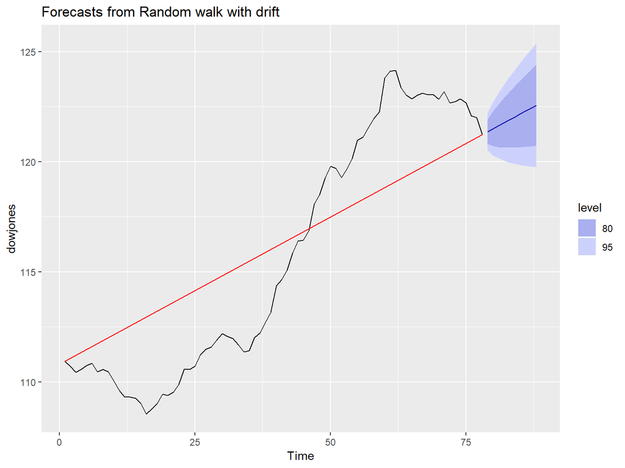

```r
autoplot(driftDj) +
  geom_line(aes(x = c(1, 78),
                y = dowjones[c(1, 78)]),
            colour = "red")
```

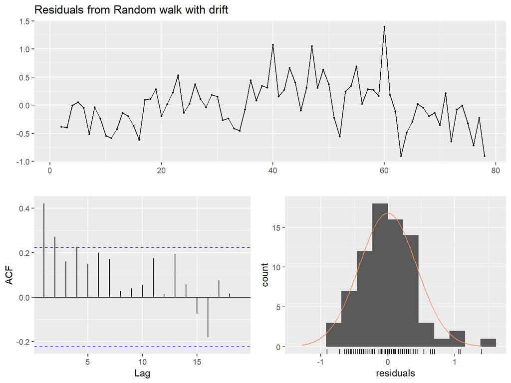

```
##
##  Ljung-Box test
##
## data:  Residuals from Random walk with drift
## Q* = 35.039, df = 9, p-value = 5.865e-05
##
## Model df: 1.   Total lags used: 10
```

```r
# d. Try using some of the other benchmark functions to forecast the same data set. Which do you think is best? Why?
checkresiduals(driftDj)
```

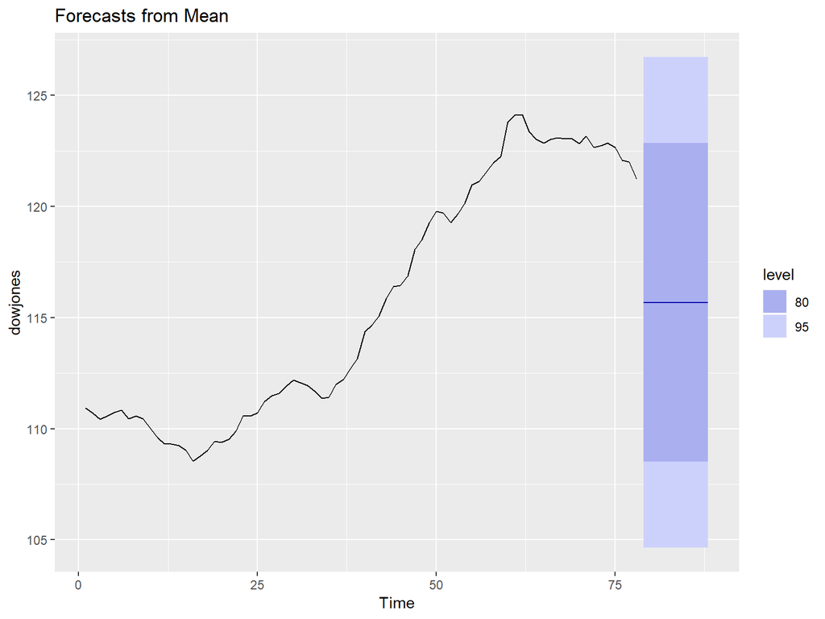

```r
meanDj <- meanf(dowjones)
autoplot(meanDj)
```